# Modelo Room 8

Juan Carlos Jimenez y Juan José Espín

2024-02-17

#Librarias

```r
library(tidyverse)
library(magrittr)
library(skimr)
library(janitor)
library(tidymodels)
library(ranger)
library(xgboost)
library(vip)
```

#Cargar datos

```r
data <- read_csv('Data/WA_Fn-UseC_-Telco-Customer-Churn.csv',
                 show_col_types = FALSE)
```

#Verificar y corregir columnas

### Verificar base de datos con glimpse

```r
data %>%
        glimpse
```

```
## Rows: 7,043
## Columns: 21
## $ customerID       <chr> "7590-VHVEG", "5575-GNVDE", "3668-QPYBK", "7795-CFOCW…
## $ gender           <chr> "Female", "Male", "Male", "Male", "Female", "Female",…
## $ SeniorCitizen    <dbl> 0, 0, 0, 0, 0, 0, 0, 0, 0, 0, 0, 0, 0, 0, 0, 0, 0, 0,…
## $ Partner          <chr> "Yes", "No", "No", "No", "No", "No", "No", "No", "Yes…
## $ Dependents       <chr> "No", "No", "No", "No", "No", "No", "Yes", "No", "No"…
## $ tenure           <dbl> 1, 34, 2, 45, 2, 8, 22, 10, 28, 62, 13, 16, 58, 49, 2…
## $ PhoneService     <chr> "No", "Yes", "Yes", "No", "Yes", "Yes", "Yes", "No", …
## $ MultipleLines    <chr> "No phone service", "No", "No", "No phone service", "…
## $ InternetService  <chr> "DSL", "DSL", "DSL", "DSL", "Fiber optic", "Fiber opt…
## $ OnlineSecurity   <chr> "No", "Yes", "Yes", "Yes", "No", "No", "No", "Yes", "…
## $ OnlineBackup     <chr> "Yes", "No", "Yes", "No", "No", "No", "Yes", "No", "N…
## $ DeviceProtection <chr> "No", "Yes", "No", "Yes", "No", "Yes", "No", "No", "Y…
## $ TechSupport      <chr> "No", "No", "No", "Yes", "No", "No", "No", "No", "Yes…
## $ StreamingTV      <chr> "No", "No", "No", "No", "No", "Yes", "Yes", "No", "Ye…
## $ StreamingMovies  <chr> "No", "No", "No", "No", "No", "Yes", "No", "No", "Yes…
## $ Contract         <chr> "Month-to-month", "One year", "Month-to-month", "One …
## $ PaperlessBilling <chr> "Yes", "No", "Yes", "No", "Yes", "Yes", "Yes", "No", …
## $ PaymentMethod    <chr> "Electronic check", "Mailed check", "Mailed check", "…
## $ MonthlyCharges   <dbl> 29.85, 56.95, 53.85, 42.30, 70.70, 99.65, 89.10, 29.7…
## $ TotalCharges     <dbl> 29.85, 1889.50, 108.15, 1840.75, 151.65, 820.50, 1949…
## $ Churn            <chr> "No", "No", "Yes", "No", "Yes", "Yes", "No", "No", "Y…
```

### Verificar base de datos y convertir en factor

```r
data %>%
        summarise_all(list(
                .n=~sum(!is.na(.)),
                .na=~sum(is.na(.)),
                .min=~min(.,na.rm = T),
                .max=~max(.,na.rm = T),
                .clase=~class(.),
                .valor_distinto=~n_distinct(.)
        )) %>% mutate(across(everything(),~as.character(.))) %>%
        pivot_longer(everything(),
                     names_to = c("varible",".value"),
                     names_sep = c("_\\.")) %>% gt::gt()
```

| varible | n | na | min | max | clase | valor_distinto |
| --- | --- | --- | --- | --- | --- | --- |
| customerID | 7043 | 0 | 0002-ORFBO | 9995-HOTOH | character | 7043 |
| gender | 7043 | 0 | Female | Male | character | 2 |
| SeniorCitizen | 7043 | 0 | 0 | 1 | numeric | 2 |
| Partner | 7043 | 0 | No | Yes | character | 2 |
| Dependents | 7043 | 0 | No | Yes | character | 2 |
| tenure | 7043 | 0 | 0 | 72 | numeric | 73 |
| PhoneService | 7043 | 0 | No | Yes | character | 2 |
| MultipleLines | 7043 | 0 | No | Yes | character | 3 |
| InternetService | 7043 | 0 | DSL | No | character | 3 |
| OnlineSecurity | 7043 | 0 | No | Yes | character | 3 |
| OnlineBackup | 7043 | 0 | No | Yes | character | 3 |
| DeviceProtection | 7043 | 0 | No | Yes | character | 3 |
| TechSupport | 7043 | 0 | No | Yes | character | 3 |
| StreamingTV | 7043 | 0 | No | Yes | character | 3 |
| StreamingMovies | 7043 | 0 | No | Yes | character | 3 |
| Contract | 7043 | 0 | Month-to-month | Two year | character | 3 |
| PaperlessBilling | 7043 | 0 | No | Yes | character | 2 |
| PaymentMethod | 7043 | 0 | Bank transfer (automatic) | Mailed check | character | 4 |
| MonthlyCharges | 7043 | 0 | 18.25 | 118.75 | numeric | 1585 |
| TotalCharges | 7032 | 11 | 18.8 | 8684.8 | numeric | 6531 |
| Churn | 7043 | 0 | No | Yes | character | 2 |

```r
#Convertir a factor
data %>%
  mutate( Churn = factor(Churn,
  levels= c("Yes","No"),
  labels= c("si", "no"))
  ) -> data


data %>%
  mutate(
    SeniorCitizen = factor(SeniorCitizen,
                           levels = c(0, 1), labels = c('no', 'si')),
    gender = factor(gender,
                    levels = c('Female', 'Male'), labels = c('Mujeres', 'Hombres')),
    Partner = factor(Partner,
                     levels = c('Yes', 'No'), labels = c('si', 'No')),
    Dependents = factor(Dependents,
                        levels = c('Yes', 'No'), labels = c('si', 'No')),
    PhoneService = factor(PhoneService,
                          levels = c('Yes', 'No'), labels = c('si', 'No')),
    PaperlessBilling = factor(PaperlessBilling,
                              levels = c('Yes', 'No'), labels = c('si', 'No')),
    MultipleLines = factor(MultipleLines,
                           levels = c('Yes', 'No', "No phone service"), labels = c('si', 'no', 'sin servicio')),
    InternetService = factor(InternetService,
                             levels = c('DSL', 'Fiber optic', 'No'), labels = c('DSL', 'Fibra optica', 'No')),
    OnlineSecurity = factor(OnlineSecurity,
                            levels = c('No', 'Yes', 'No internet service'), labels = c('No', 'Yes', 'sin servicio')),
    OnlineBackup = factor(OnlineBackup,
                          levels = c('Yes', 'No', 'No internet service'), labels = c('si', 'no', 'sin servicio')),
    DeviceProtection = factor(DeviceProtection,
                              levels = c('Yes', 'No', 'No internet service'), labels = c('si', 'no', 'sin servicio')),
    TechSupport = factor(TechSupport,
                         levels = c('Yes', 'No', 'No internet service'), labels = c('si', 'no', 'sin servicio')),
    StreamingTV = factor(StreamingTV,
                         levels = c('Yes', 'No', 'No internet service'), labels = c('si', 'no', 'sin servicio')),
    StreamingMovies = factor(StreamingMovies,
                             levels = c('Yes', 'No', 'No internet service'), labels = c('si', 'no', 'sin servicio')),
    Contract = factor(Contract,
                      levels = c('Month-to-month', 'One year', 'Two year'), labels = c('mes a mes', 'un año', 'dos años')),
    PaymentMethod = factor(PaymentMethod,
                           levels = c('Electronic check', 'Mailed check', 'Bank transfer (automatic)', 'Credit card (automatic)'),
                           labels = c('cheque electronico', 'cheque mail', 'transferencia bancaria', 'transferencia automatica'))
  ) -> data
```

#EDA

### EDA Univariado

#### Todas las variables

```r
skim(data)
```

Data summary

| Name | data |
| --- | --- |
| Number of rows | 7043 |
| Number of columns | 21 |
| _______________________ |  |
| Column type frequency: |  |
| character | 1 |
| factor | 17 |
| numeric | 3 |
| ________________________ |  |
| Group variables | None |

**Variable type: character**

| skim_variable | n_missing | complete_rate | min | max | empty | n_unique | whitespace |
| --- | --- | --- | --- | --- | --- | --- | --- |
| customerID | 0 | 1 | 10 | 10 | 0 | 7043 | 0 |

**Variable type: factor**

| skim_variable | n_missing | complete_rate | ordered | n_unique | top_counts |
| --- | --- | --- | --- | --- | --- |
| gender | 0 | 1 | FALSE | 2 | Hom: 3555, Muj: 3488 |
| SeniorCitizen | 0 | 1 | FALSE | 2 | no: 5901, si: 1142 |
| Partner | 0 | 1 | FALSE | 2 | No: 3641, si: 3402 |
| Dependents | 0 | 1 | FALSE | 2 | No: 4933, si: 2110 |
| PhoneService | 0 | 1 | FALSE | 2 | si: 6361, No: 682 |
| MultipleLines | 0 | 1 | FALSE | 3 | no: 3390, si: 2971, sin: 682 |
| InternetService | 0 | 1 | FALSE | 3 | Fib: 3096, DSL: 2421, No: 1526 |
| OnlineSecurity | 0 | 1 | FALSE | 3 | No: 3498, Yes: 2019, sin: 1526 |
| OnlineBackup | 0 | 1 | FALSE | 3 | no: 3088, si: 2429, sin: 1526 |
| DeviceProtection | 0 | 1 | FALSE | 3 | no: 3095, si: 2422, sin: 1526 |
| TechSupport | 0 | 1 | FALSE | 3 | no: 3473, si: 2044, sin: 1526 |
| StreamingTV | 0 | 1 | FALSE | 3 | no: 2810, si: 2707, sin: 1526 |
| StreamingMovies | 0 | 1 | FALSE | 3 | no: 2785, si: 2732, sin: 1526 |
| Contract | 0 | 1 | FALSE | 3 | mes: 3875, dos: 1695, un : 1473 |
| PaperlessBilling | 0 | 1 | FALSE | 2 | si: 4171, No: 2872 |
| PaymentMethod | 0 | 1 | FALSE | 4 | che: 2365, che: 1612, tra: 1544, tra: 1522 |
| Churn | 0 | 1 | FALSE | 2 | no: 5174, si: 1869 |

**Variable type: numeric**

| skim_variable | n_missing | complete_rate | mean | sd | p0 | p25 | p50 | p75 | p100 | hist |
| --- | --- | --- | --- | --- | --- | --- | --- | --- | --- | --- |
| tenure | 0 | 1 | 32.37 | 24.56 | 0.00 | 9.00 | 29.00 | 55.00 | 72.00 | ▇▃▃▃▆ |
| MonthlyCharges | 0 | 1 | 64.76 | 30.09 | 18.25 | 35.50 | 70.35 | 89.85 | 118.75 | ▇▅▆▇▅ |
| TotalCharges | 11 | 1 | 2283.30 | 2266.77 | 18.80 | 401.45 | 1397.47 | 3794.74 | 8684.80 | ▇▂▂▂▁ |

#### Posibles outliers

```r
data %>%
  reframe(
    tibble(
      Descrip= c('P_0', 'P_02', 'P_25', 'P_50' , 'P_75', 'P_98', 'P_100') ,
      Valor= quantile( TotalCharges, c(0, 0.2, 0.25, 0.50 ,0.75, 0.98, 1), na.rm= T)
    )
    ) %>%
        gt::gt()
```

| Descrip | Valor |
| --- | --- |
| P_0 | 18.800 |
| P_02 | 267.070 |
| P_25 | 401.450 |
| P_50 | 1397.475 |
| P_75 | 3794.738 |
| P_98 | 7721.096 |
| P_100 | 8684.800 |

```r
#Media por Partner
data %>%
        group_by(Partner) %>%
        summarise(media=mean(TotalCharges,
                          na.rm =T )) %>%
        gt::gt()
```

| Partner | media |
| --- | --- |
| si | 3032.272 |
| No | 1584.960 |

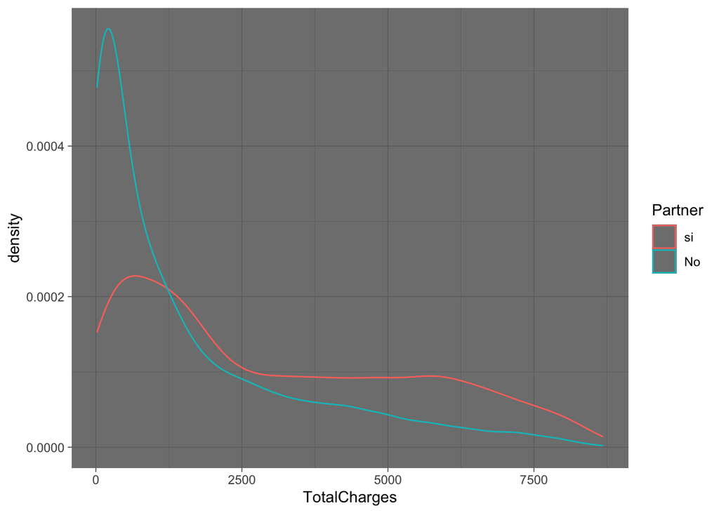

```r
#Distribuciòn de TotalCharges por Partner
data %>%
        ggplot(aes(TotalCharges,
                   color=Partner))+
        geom_density()+
        scale_y_continuous(labels = scales::number_format())+
        theme_dark()
```

Existe una diferencia importante en los registros de dinero cobrado a los clientes al considerar aquellos que tienen pareja. Al revisar el gráfico anterior, se evidencia que las personas que informaron tener pareja son las que presentan los cobros más altos. Esto se refleja en la distribución, donde se observa una densidad mayor para valores altos en comparación con las personas que declararon no tener pareja.

### EDA Bivariado

#### Churn vs SeniorCitizen

```r
data %>%
  group_by(SeniorCitizen, Churn) %>%
  summarise(
    N = n(),
    Porc = round(100*N/nrow(data),2)
  ) %>%
  mutate(Porc_grupo = round(100*N/sum(N),2)) -> valores_Sc
valores_Sc %>%
        ungroup() %>%
        gt::gt()
```

| SeniorCitizen | Churn | N | Porc | Porc_grupo |
| --- | --- | --- | --- | --- |
| no | si | 1393 | 19.78 | 23.61 |
| no | no | 4508 | 64.01 | 76.39 |
| si | si | 476 | 6.76 | 41.68 |
| si | no | 666 | 9.46 | 58.32 |

```r
# Comentado por conflictos con paquete
# tigerstats::rowPerc(xtabs(~SeniorCitizen+Churn, data=data) )
```

#### Churn vs SeniorCitizen vs Porc_grupo

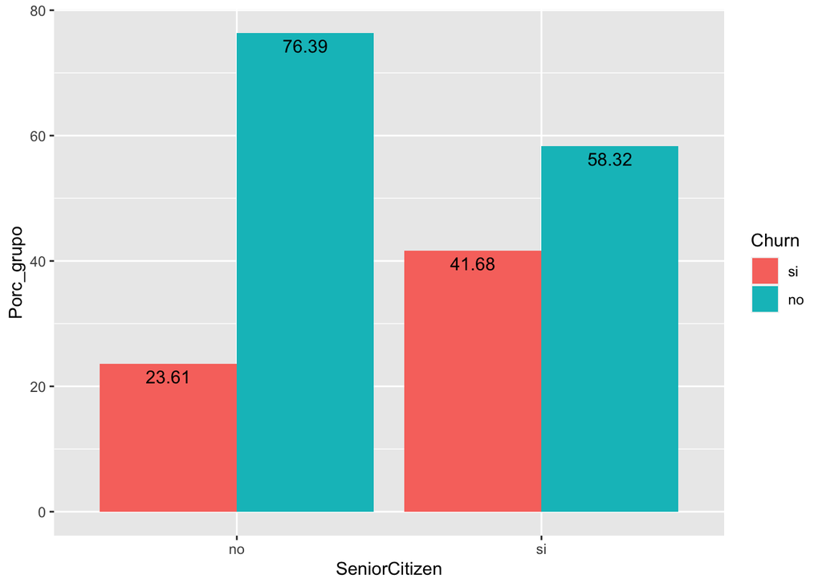

```r
ggplot(valores_Sc, aes(x = SeniorCitizen, y = Porc_grupo, fill = Churn)) +
  geom_col(stat = "identity", position = "dodge") +
  geom_text(aes(label = Porc_grupo), vjust = 1.5,
            position = position_dodge(.9))
```

De los adultos mayores el 41% abandonó el servicio, mientras que de los no adultos mayores apenas un 24% abandonó el servicio. Aparentemente, un adulto mayor tiene mayor probabilidad de abandonar el servicio.

#### Churn vs MultipleLines

```r
valores_Ml <- data %>%
        count(Churn,MultipleLines) %>%
        group_by(Churn) %>%
        mutate(n_chur=sum(n),
               porcentaje_personas=n/n_chur) %>%
        ungroup()

valores_Ml %>%
        gt::gt()%>%
        gt::fmt_percent(columns=porcentaje_personas)
```

| Churn | MultipleLines | n | n_chur | porcentaje_personas |
| --- | --- | --- | --- | --- |
| si | si | 850 | 1869 | 45.48% |
| si | no | 849 | 1869 | 45.43% |
| si | sin servicio | 170 | 1869 | 9.10% |
| no | si | 2121 | 5174 | 40.99% |
| no | no | 2541 | 5174 | 49.11% |
| no | sin servicio | 512 | 5174 | 9.90% |

######Gráfico

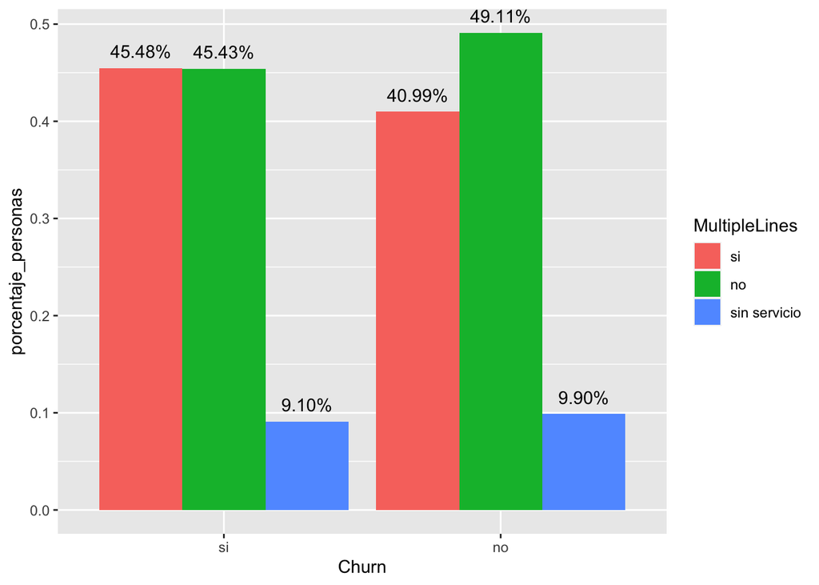

```r
valores_Ml %>%
        ggplot(aes(Churn, y = porcentaje_personas, fill = MultipleLines)) +
        geom_col(position = "dodge") +
        geom_text(aes(label = scales::percent(porcentaje_personas,accuracy = 0.01)), vjust = -0.8,
                  position = position_dodge(.9))
```

Entre las categorías de MultipleLines no hay mayor diferencia, entre los que abandonan o no el servicio. Los porcentajes son muy parecidos.

#### Churn vs TechSupport

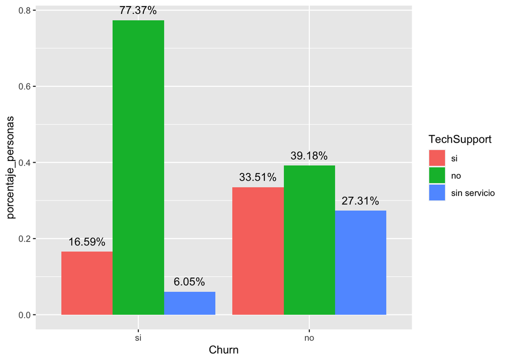

```r
data %>%
        count(Churn,TechSupport) %>%
        group_by(Churn) %>%
        mutate(n_chur=sum(n),
               porcentaje_personas=n/n_chur) %>%
        ungroup() %>%
        ggplot(aes(Churn,
                   porcentaje_personas,
                   fill = TechSupport)) +
        geom_col(position = "dodge") +
        geom_text(aes(label = scales::percent(porcentaje_personas,
                                              accuracy = 0.01)),
                  vjust = -0.8,
                  position = position_dodge(.9))
```

Las personas que se van de la compañía en promedio el 77.37% no tienen soporte técnico y solo el 16.59% de los que se van indican tener soporte técnico.

#### Churn vs PaymentMethod

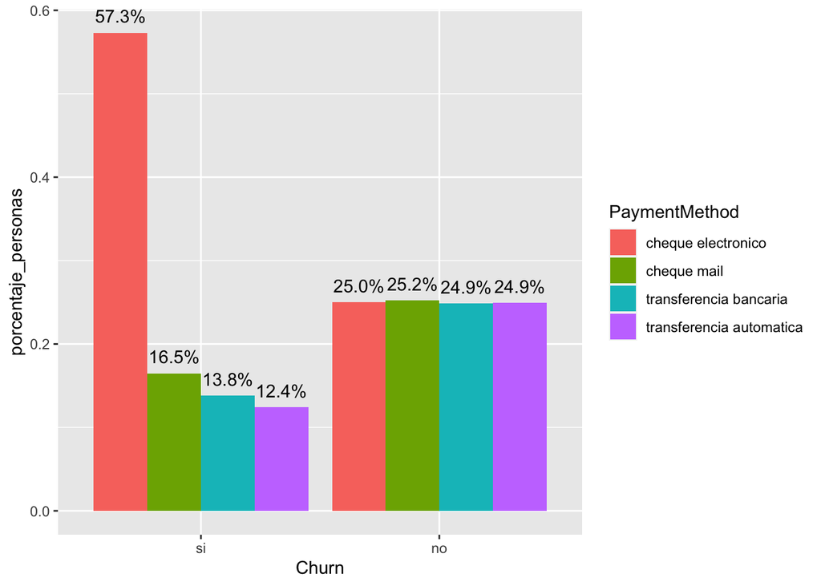

```r
data %>%
        count(Churn,PaymentMethod) %>%
        group_by(Churn) %>%
        mutate(n_chur=sum(n),
               porcentaje_personas=n/n_chur) %>%
        ungroup() %>%
        ggplot(aes(Churn,
                   porcentaje_personas,
                   fill = PaymentMethod)) +
        geom_col(position = "dodge") +
        geom_text(aes(label = scales::percent(porcentaje_personas,
                                              accuracy = 0.1)),
                  vjust = -0.8,
                  position = position_dodge(.9))
```

#### Churn vs Dependents

```r
data %>% tabyl(Churn, Dependents ) -> t1

t1 %>% adorn_totals(c("row", "col")) %>% adorn_percentages("all") %>%
adorn_pct_formatting(rounding = "half up", digits = 0) %>% adorn_ns() %>%
  adorn_title("combined") %>% knitr::kable()
```

| Churn/Dependents | si | No | Total |
| --- | --- | --- | --- |
| si | 5% (326) | 22% (1,543) | 27% (1,869) |
| no | 25% (1,784) | 48% (3,390) | 73% (5,174) |
| Total | 30% (2,110) | 70% (4,933) | 100% (7,043) |

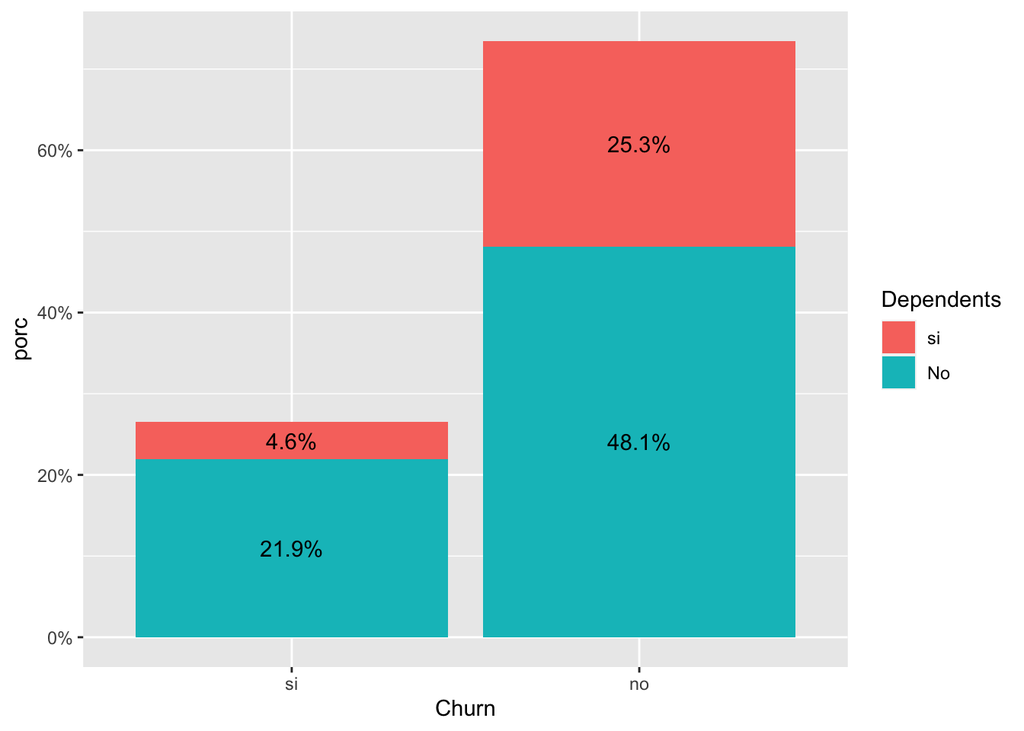

```r
data %>% count(Churn, Dependents) %>%
  mutate(porc = n / sum(n)) %>%
  ggplot(aes(fill=Dependents, y=porc, x=Churn)) +
    geom_col(position="stack") +
    geom_text(aes(label=scales::percent(porc)),position = position_stack(vjust=0.5))+
  scale_y_continuous(labels = scales::percent_format())
```

#### Churn vs OnlineSecurity

```r
data %>% tabyl(Churn,OnlineSecurity ) -> t2

t2 %>% adorn_totals(c("row", "col")) %>% adorn_percentages("all") %>%
adorn_pct_formatting(rounding = "half up", digits = 0) %>% adorn_ns()%>% adorn_title("combined")%>% knitr::kable()
```

| Churn/OnlineSecurity | No | Yes | sin servicio | Total |
| --- | --- | --- | --- | --- |
| si | 21% (1,461) | 4% (295) | 2% (113) | 27% (1,869) |
| no | 29% (2,037) | 24% (1,724) | 20% (1,413) | 73% (5,174) |
| Total | 50% (3,498) | 29% (2,019) | 22% (1,526) | 100% (7,043) |

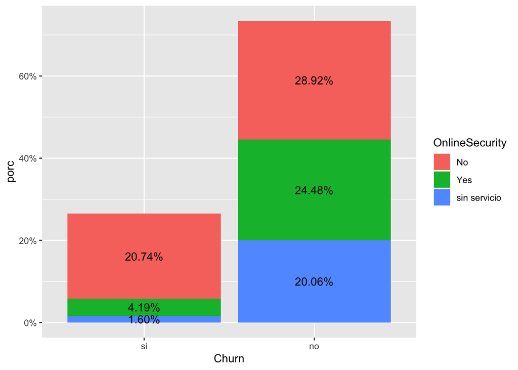

```r
data %>% count(Churn, OnlineSecurity) %>%
  mutate(porc = n / sum(n)) %>%
  ggplot(aes(fill=OnlineSecurity, y=porc, x=Churn)) +
    geom_col(position="stack") +
    geom_text(aes(label=scales::percent(porc)),position = position_stack(vjust=0.5))+
  scale_y_continuous(labels = scales::percent_format())
```

El 20,74% de los indviduos analizados y que abandonaron el servicio no contaban con seguridad en línea. Por otro lado aquellos que no salieron del plan reflejaron una participación similar con relación al servicio de seguridad en línea.

#### Churn vs StreamingMovies

```r
data %>% tabyl(Churn,StreamingMovies) -> t3

t3 %>% adorn_totals(c("row", "col")) %>% adorn_percentages("all") %>%
adorn_pct_formatting(rounding = "half up", digits = 0) %>% adorn_ns()%>% adorn_title("combined")%>% knitr::kable()
```

| Churn/StreamingMovies | si | no | sin servicio | Total |
| --- | --- | --- | --- | --- |
| si | 12% (818) | 13% (938) | 2% (113) | 27% (1,869) |
| no | 27% (1,914) | 26% (1,847) | 20% (1,413) | 73% (5,174) |
| Total | 39% (2,732) | 40% (2,785) | 22% (1,526) | 100% (7,043) |

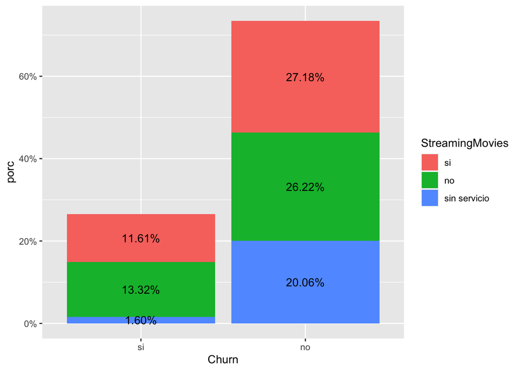

```r
data %>% count(Churn, StreamingMovies) %>%
  mutate(porc = n / sum(n)) %>%
  ggplot(aes(fill=StreamingMovies, y=porc, x=Churn)) +
    geom_col(position="stack") +
    geom_text(aes(label=scales::percent(porc)),position = position_stack(vjust=0.5))+
  scale_y_continuous(labels = scales::percent_format())
```

El 13,32% de los indviduos analizados y que abandonaron el servicio no contaban con servicio de Streaming Movies. Sin embargo, tanto para el grupo que abandonaron o mantuvieron el servicio no se evidencia una importancia relevante para su salidad del plan.

#### Churn vs Total Charges

```r
data %>%  group_by(Churn) %>%
  summarise(n = n(),
            promedio = mean(TotalCharges,na.rm = T),
            n_missing = sum(is.na(TotalCharges)),
            desv = sd(TotalCharges, na.rm =T)) -> t4
t4 %>%
        gt::gt()
```

| Churn | n | promedio | n_missing | desv |
| --- | --- | --- | --- | --- |
| si | 1869 | 1531.796 | 0 | 1890.823 |
| no | 5174 | 2555.344 | 11 | 2329.457 |

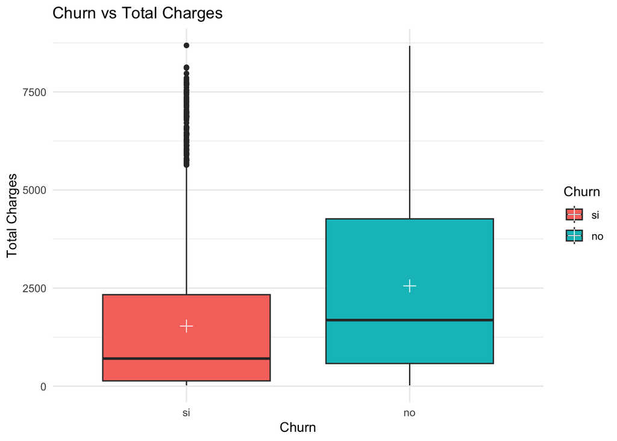

```r
data %>%
  ggplot(aes(x = Churn, y = TotalCharges, fill = Churn)) +
  geom_boxplot() +
  stat_summary(fun = mean, geom = "point", shape = 3, size = 3,
               color = "white", position = position_dodge(width = 0.75)) +
  labs(title = "Churn vs Total Charges",
       x = "Churn",
       y = "Total Charges") +
        theme_minimal()
```

En promedio el gasto total en el servicio de telecomunicaciones para los individuos que salieron del plan es inferior por usuario en alrededor de USD 1000. Para los usuarios que salieron del servicio se evidencia datos atípicos elevados que alcanzan los valores máximos de los usarios que no salieron del servicio. Cabe señalar que, para los usuarios que no abandoron el servicio su extipendio total del plan se concentra entre el rango intercuartílico. Adicionalmente, se observa que la variable gasto total cuenta con 11 valores perdidos.

### EDA Multivariado

#### Churn vs MonthlyCharges vs PaymentMethod

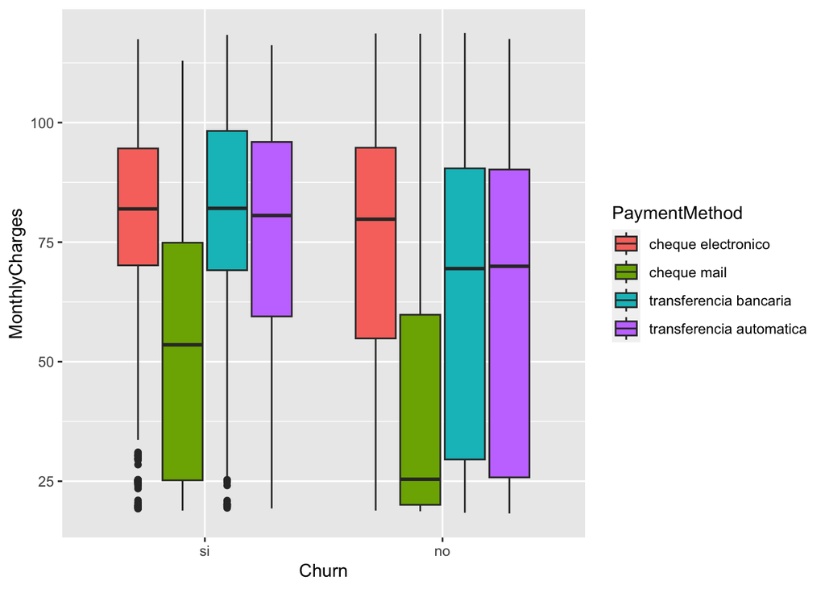

```r
ggplot(data, aes(x = Churn, y = MonthlyCharges, fill = PaymentMethod)) +
  geom_boxplot()
```

Los montos de pago de aquellos que abandonan el servicio son superiores a aquellos que permanecen con excepción de los que pagan por cheque electrónico.

#### Churn vs MonthlyCharges vs Dependents

```r
data %>%  group_by(Churn,Dependents) %>%
    summarise(n = n(),
            promedio = mean(MonthlyCharges,na.rm = T),
            n_missing = sum(is.na(MonthlyCharges)),
            desv = sd(MonthlyCharges, na.rm =T),
            .groups="drop")  -> t5
t5 %>%
        gt::gt() %>%
        gt::fmt_number(columns = c(promedio,desv),
                       decimals = 2)
```

| Churn | Dependents | n | promedio | n_missing | desv |
| --- | --- | --- | --- | --- | --- |
| si | si | 326 | 72.87 | 0 | 25.76 |
| si | No | 1543 | 74.77 | 0 | 24.42 |
| no | si | 1784 | 57.08 | 0 | 31.61 |
| no | No | 3390 | 63.47 | 0 | 30.59 |

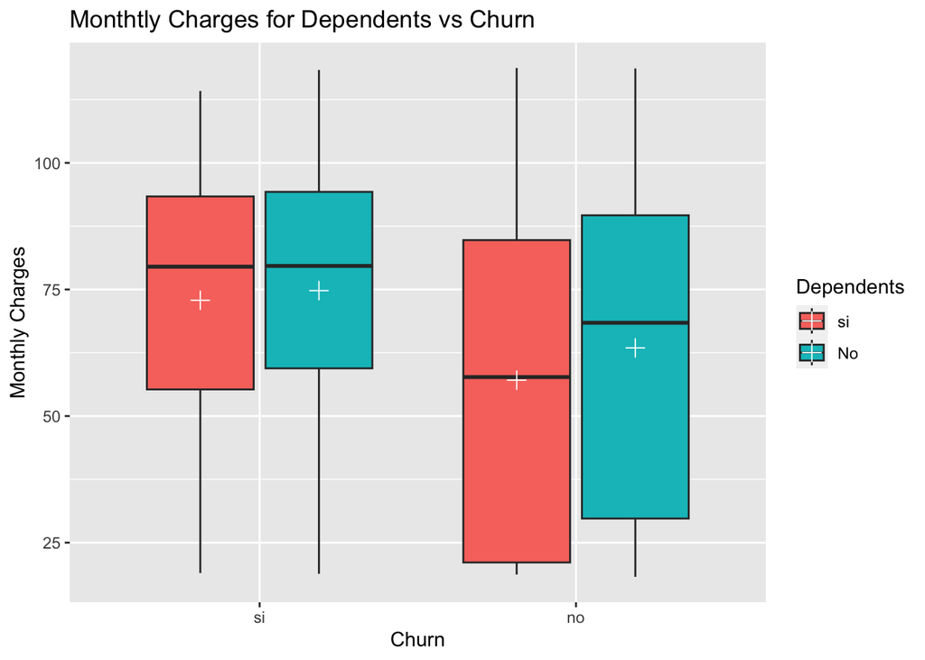

```r
data %>%
  ggplot(aes(x = Churn, y = MonthlyCharges, fill = Dependents)) +
  geom_boxplot() +
  stat_summary(fun = mean, geom = "point", shape = 3, size = 3, color = "white", position = position_dodge(width = 0.75)) +
  labs(title = "Monthtly Charges for Dependents vs Churn",
       x = "Churn",
       y = "Monthly Charges")
```

La distribución del gasto mensual de aquellos individuos que no salieron del plan se concentra dentro del cuartil 1 y cuartil 3, además entre el máximo y mínimo de los que dejaron el servicio respecto de los que se quedaron no se verifica mayor diferencia. Es importante destacar que, tanto el promedio como la mediana del pago mensual es superior en los individuos que salieron del plan de los que se quedaron, no obstante no se verifica mayor diferencia respecto de contar o no con dependientes en los usuarios que abandonaron el plan.

# Matriz de Correlación

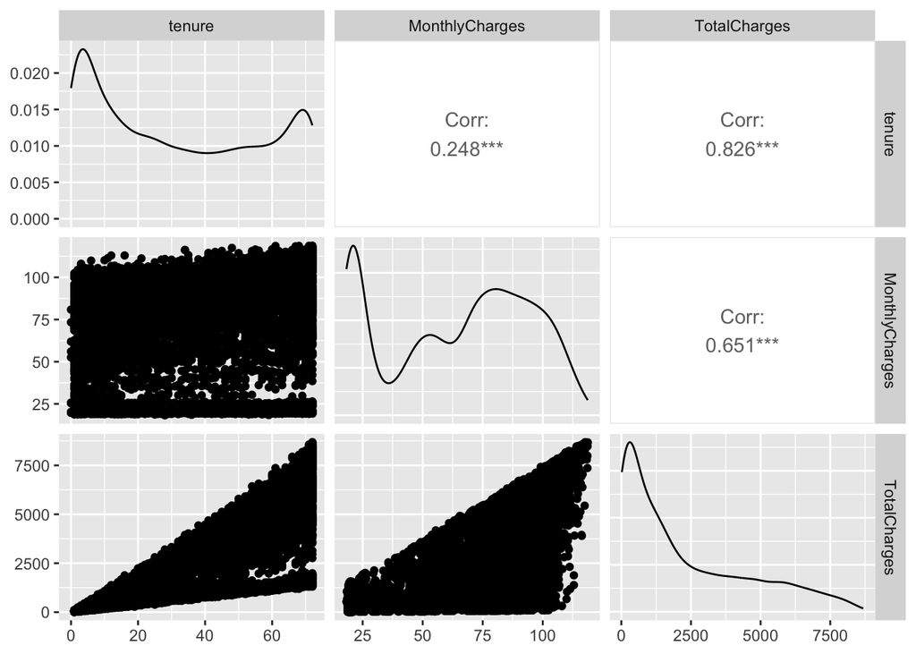

```r
data %>%  select_if(where(is.numeric)) %>% GGally::ggpairs()
```

Según el gráfico anterior existe una alta correlación positiva entre las variables TotalChanges y tenure, con 0.826, seguida de la correlación entre las variables TotalChages y MonthyChanges, con una correlación moderada de 0.651.

# Revisión del balanceo de datos

```r
data %>%
  group_by(Churn) %>%
  count(name = "frec") %>%
        ungroup() %>%
        mutate( Porc= frec/sum(frec)) %>%
        gt::gt() %>%
        gt::fmt_percent(columns=Porc)
```

| Churn | frec | Porc |
| --- | --- | --- |
| si | 1869 | 26.54% |
| no | 5174 | 73.46% |

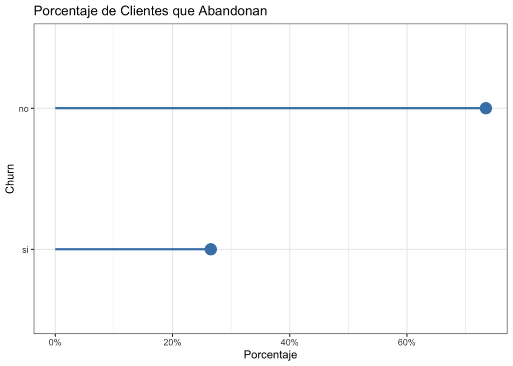

```r
data %>%
group_by(Churn) %>%
count( name = 'frec') %>%
ungroup() %>%
mutate( Porc= frec/sum(frec)) %>%
ggplot( aes(x= Churn, y= Porc)) +
geom_segment( aes(xend= Churn, y=0, yend=Porc),
color= "steelblue", linewidth= 1) +
geom_point( size=5, color= "steelblue") +
coord_flip() +
scale_y_continuous( labels = percent_format()) +
labs(title= 'Porcentaje de Clientes que Abandonan',
y= "Porcentaje", x= "Churn") +
theme_bw()
```

El porcentaje de clientes que abandonan el servicio de telecomunicaciones es aproximadamente 3 a 1 en el muestra de análisis.

# MODELAMIENTO

### Train - Test Split

```r
#data %>% select(-customerID) -> data

set.seed(1234) # Semilla para aleatorios
split <- data %>%
initial_split(
prop = 0.8, # Porcentaje al train
strata = Churn # Estratificación del muestreo
)
```

### Data de entrenamiento

```r
train <- training(split)
dim(train)
```

```
## [1] 5634   21
```

### Data de prueba (test)

```r
test <- testing(split)
dim(test)
```

```
## [1] 1409   21
```

### Preprocesamiento

#### Receipe y Balanceo de datos

```r
receta <- train %>%
recipe(Churn ~ . ) %>% ## Crea la receta
## Eliminar variables que no usaremos
step_rm(customerID) %>%
## Crear nuevas variables (insight desde el EDA)
# step_mutate( account_length_anio= account_length/12 )
## Imputar los datos
# step_impute_mean()
step_impute_knn(TotalCharges ) %>%
## Estandarizacion/Normalizacion de numericas
step_normalize( all_numeric(), -all_outcomes()) %>%
## Crear una categoría "otros" que agrupe a categorias pequeñas
step_other(all_nominal(), -all_outcomes() , threshold = 0.07, other = "otros") %>%
## Crear una categoría "new" para observaciones con labels "no muestreados"
step_novel(all_nominal(), -all_outcomes() , new_level = "new") %>%
## Crear variables indicadoras para cada categoría
step_dummy(all_nominal(), -all_outcomes() ) %>% # Dummy
## Eliminar automáticamente variables con alta correlacion
## para evitar la multicolinealidad xi ~ xj
# step_corr(all_numeric(), -all_outcomes(), threshold = 0.9) %>%
## Tambien podemos eliminar variables con multicolinealidad "a mano"
#step_rm(total_day_charge, total_eve_charge,
#total_night_charge, total_intl_charge) %>% # Eliminar
## Eliminar columnas con varianza cercana a cero
step_nzv(all_predictors()) %>%
themis::step_upsample(Churn, over_ratio = 0.9, skip= TRUE, seed= 123)
```

#### Entrenamiento y ajuste de Hiperparámetro

```r
set.seed(1234)
cv <- vfold_cv(train, v = 5, repeats = 1, strata = Churn)
cv
```

```
## #  5-fold cross-validation using stratification
## # A tibble: 5 × 2
##   splits              id
##   <list>              <chr>
## 1 <split [4507/1127]> Fold1
## 2 <split [4507/1127]> Fold2
## 3 <split [4507/1127]> Fold3
## 4 <split [4507/1127]> Fold4
## 5 <split [4508/1126]> Fold5
```

### Métricas

```r
metricas <- metric_set(accuracy, sens, spec, bal_accuracy)
metricas
```

```
## A metric set, consisting of:
## - `accuracy()`, a class metric     | direction: maximize
## - `sens()`, a class metric         | direction: maximize
## - `spec()`, a class metric         | direction: maximize
## - `bal_accuracy()`, a class metric | direction: maximize
```

# Modelamiento - Random Forest

### Especificacion del modelo*

```r
rf_sp <-
  rand_forest(
  mtry = tune(), trees = tune(), min_n = tune() ) %>%
  set_engine("ranger", importance = "impurity") %>%
  set_mode("classification")
```

### Work Flow

```r
rf_wflow <-
  workflow() %>%
  add_recipe(receta) %>%
  add_model(rf_sp)
  rf_wflow
```

```
## ══ Workflow ════════════════════════════════════════════════════════════════════
## Preprocessor: Recipe
## Model: rand_forest()
##
## ── Preprocessor ────────────────────────────────────────────────────────────────
## 8 Recipe Steps
##
## • step_rm()
## • step_impute_knn()
## • step_normalize()
## • step_other()
## • step_novel()
## • step_dummy()
## • step_nzv()
## • step_upsample()
##
## ── Model ───────────────────────────────────────────────────────────────────────
## Random Forest Model Specification (classification)
##
## Main Arguments:
##   mtry = tune()
##   trees = tune()
##   min_n = tune()
##
## Engine-Specific Arguments:
##   importance = impurity
##
## Computational engine: ranger
```

### Afinamiento de Hiperpárametros

```r
set.seed(123)
rf_grid <- rf_sp %>%
## preguntamos los parametros tuneables del modelo
parameters() %>%
## Vamos a definir un rango para el min_n y mtry
update(min_n= min_n( range= c(70, 170)),
mtry= mtry( range= c(4, 7))) %>%
grid_latin_hypercube(size = 10) #preguntar como se construye la malla
```

La data luego de aplicar la receta registra 31 variables, por tanto, se utiliza como criterio para establecer el hiperpárametro “mtry” la raíz cuadrada del número de variables analizadas siendo esta igual a 5,56. En tal sentido, y con la finalidad de contar con un rango para la elección de variables este se establece entre 4 a 7.

###Paralelización

```r
#parallel::detectCores(logical=FALSE)
```

### Entrenamiento de Malla de Búsqueda en la Crossvalidation

```r
set.seed(123)
rf_tuned <- tune_grid(
        rf_wflow, ## Modelo
        resamples= cv, ## Crossvalidation
        grid = rf_grid, ## Malla de Busqueda
        metrics = metricas, ## Metricas
        control= control_grid(allow_par = T, save_pred = T) ## Paralel y Pred
)
rf_tuned
```

```
## # Tuning results
## # 5-fold cross-validation using stratification
## # A tibble: 5 × 5
##   splits              id    .metrics          .notes           .predictions
##   <list>              <chr> <list>            <list>           <list>
## 1 <split [4507/1127]> Fold1 <tibble [40 × 7]> <tibble [0 × 3]> <tibble>
## 2 <split [4507/1127]> Fold2 <tibble [40 × 7]> <tibble [0 × 3]> <tibble>
## 3 <split [4507/1127]> Fold3 <tibble [40 × 7]> <tibble [0 × 3]> <tibble>
## 4 <split [4507/1127]> Fold4 <tibble [40 × 7]> <tibble [0 × 3]> <tibble>
## 5 <split [4508/1126]> Fold5 <tibble [40 × 7]> <tibble [0 × 3]> <tibble>
```

### Evaluación de modelos Evaluamos que modelo resulto mejor

```r
show_best(rf_tuned, metric = 'accuracy', n = 10)
```

```
## # A tibble: 10 × 9
##     mtry trees min_n .metric  .estimator  mean     n std_err .config
##    <int> <int> <int> <chr>    <chr>      <dbl> <int>   <dbl> <chr>
##  1     4  1370   116 accuracy binary     0.769     5 0.00960 Preprocessor1_Mode…
##  2     5   325    83 accuracy binary     0.768     5 0.00838 Preprocessor1_Mode…
##  3     6   467    91 accuracy binary     0.767     5 0.00997 Preprocessor1_Mode…
##  4     7   773    80 accuracy binary     0.767     5 0.00904 Preprocessor1_Mode…
##  5     5    70   144 accuracy binary     0.767     5 0.00933 Preprocessor1_Mode…
##  6     5  1904   126 accuracy binary     0.767     5 0.0100  Preprocessor1_Mode…
##  7     6   950   130 accuracy binary     0.766     5 0.00975 Preprocessor1_Mode…
##  8     5  1441   106 accuracy binary     0.765     5 0.00994 Preprocessor1_Mode…
##  9     6  1124   162 accuracy binary     0.765     5 0.00997 Preprocessor1_Mode…
## 10     6  1737   158 accuracy binary     0.765     5 0.0100  Preprocessor1_Mode…
```

```r
show_best(rf_tuned, metric = 'sens', n = 10)
```

```
## # A tibble: 10 × 9
##     mtry trees min_n .metric .estimator  mean     n std_err .config
##    <int> <int> <int> <chr>   <chr>      <dbl> <int>   <dbl> <chr>
##  1     5    70   144 sens    binary     0.738     5 0.0130  Preprocessor1_Model…
##  2     4  1370   116 sens    binary     0.736     5 0.0168  Preprocessor1_Model…
##  3     6  1737   158 sens    binary     0.735     5 0.0126  Preprocessor1_Model…
##  4     6  1124   162 sens    binary     0.735     5 0.0126  Preprocessor1_Model…
##  5     6   950   130 sens    binary     0.734     5 0.0117  Preprocessor1_Model…
##  6     5  1904   126 sens    binary     0.734     5 0.0129  Preprocessor1_Model…
##  7     5  1441   106 sens    binary     0.732     5 0.0144  Preprocessor1_Model…
##  8     5   325    83 sens    binary     0.728     5 0.0113  Preprocessor1_Model…
##  9     6   467    91 sens    binary     0.728     5 0.0115  Preprocessor1_Model…
## 10     7   773    80 sens    binary     0.720     5 0.00913 Preprocessor1_Model…
```

```r
show_best(rf_tuned, metric = 'spec', n = 10)
```

```
## # A tibble: 10 × 9
##     mtry trees min_n .metric .estimator  mean     n std_err .config
##    <int> <int> <int> <chr>   <chr>      <dbl> <int>   <dbl> <chr>
##  1     7   773    80 spec    binary     0.784     5 0.00913 Preprocessor1_Model…
##  2     5   325    83 spec    binary     0.782     5 0.00749 Preprocessor1_Model…
##  3     6   467    91 spec    binary     0.782     5 0.00951 Preprocessor1_Model…
##  4     4  1370   116 spec    binary     0.780     5 0.00756 Preprocessor1_Model…
##  5     5  1904   126 spec    binary     0.779     5 0.00920 Preprocessor1_Model…
##  6     5    70   144 spec    binary     0.778     5 0.00869 Preprocessor1_Model…
##  7     6   950   130 spec    binary     0.777     5 0.00939 Preprocessor1_Model…
##  8     5  1441   106 spec    binary     0.777     5 0.00881 Preprocessor1_Model…
##  9     6  1124   162 spec    binary     0.776     5 0.00916 Preprocessor1_Model…
## 10     6  1737   158 spec    binary     0.776     5 0.00932 Preprocessor1_Model…
```

```r
show_best(rf_tuned, metric = 'bal_accuracy', n = 10)
```

```
## # A tibble: 10 × 9
##     mtry trees min_n .metric      .estimator  mean     n std_err .config
##    <int> <int> <int> <chr>        <chr>      <dbl> <int>   <dbl> <chr>
##  1     4  1370   116 bal_accuracy binary     0.758     5 0.0117  Preprocessor1_…
##  2     5    70   144 bal_accuracy binary     0.758     5 0.0103  Preprocessor1_…
##  3     5  1904   126 bal_accuracy binary     0.757     5 0.0109  Preprocessor1_…
##  4     6   950   130 bal_accuracy binary     0.756     5 0.0102  Preprocessor1_…
##  5     6  1124   162 bal_accuracy binary     0.755     5 0.0108  Preprocessor1_…
##  6     5   325    83 bal_accuracy binary     0.755     5 0.00925 Preprocessor1_…
##  7     6  1737   158 bal_accuracy binary     0.755     5 0.0108  Preprocessor1_…
##  8     5  1441   106 bal_accuracy binary     0.755     5 0.0112  Preprocessor1_…
##  9     6   467    91 bal_accuracy binary     0.755     5 0.0104  Preprocessor1_…
## 10     7   773    80 bal_accuracy binary     0.752     5 0.00902 Preprocessor1_…
```

Revisando los resultados de las métricas de evaluación del modelo y considerando que es de interés para le empresa contar con la mejor estimación de los individuos que realmente abandonan el servicio se selecciona como referencia los hiperpárametros del modelo número 6 que presenta los mejores resultados en sensibilidad, para ajustar el modelo final.

### Nueva Malla de Búsqueda

```r
set.seed(123)

rf_grid_2 <- crossing(
  min_n = seq(114, 118, 2),
  mtry = c(4, 5),
  trees= seq(1270, 1570, 100)
)

rf_grid_2
```

```
## # A tibble: 24 × 3
##    min_n  mtry trees
##    <dbl> <dbl> <dbl>
##  1   114     4  1270
##  2   114     4  1370
##  3   114     4  1470
##  4   114     4  1570
##  5   114     5  1270
##  6   114     5  1370
##  7   114     5  1470
##  8   114     5  1570
##  9   116     4  1270
## 10   116     4  1370
## # ℹ 14 more rows
```

### Entrenamiento de Malla de Busqueda en la Crossvalidation

```r
set.seed(123)
rf_tuned_2 <- tune_grid(
  rf_wflow, ## Modelo
  resamples= cv, ## Crossvalidation
  grid = rf_grid_2, ## Malla de Busqueda
  metrics = metricas, ## Metricas
  control= control_grid(allow_par = T, save_pred = T) ## Paralel y Pred
)
rf_tuned_2
```

```
## # Tuning results
## # 5-fold cross-validation using stratification
## # A tibble: 5 × 5
##   splits              id    .metrics          .notes           .predictions
##   <list>              <chr> <list>            <list>           <list>
## 1 <split [4507/1127]> Fold1 <tibble [96 × 7]> <tibble [0 × 3]> <tibble>
## 2 <split [4507/1127]> Fold2 <tibble [96 × 7]> <tibble [0 × 3]> <tibble>
## 3 <split [4507/1127]> Fold3 <tibble [96 × 7]> <tibble [0 × 3]> <tibble>
## 4 <split [4507/1127]> Fold4 <tibble [96 × 7]> <tibble [0 × 3]> <tibble>
## 5 <split [4508/1126]> Fold5 <tibble [96 × 7]> <tibble [0 × 3]> <tibble>
```

Evaluamos que modelo resulto mejor de la segunda grilla de hiperpárametros

```r
show_best(rf_tuned_2, metric = 'accuracy', n = 10)
```

```
## # A tibble: 10 × 9
##     mtry trees min_n .metric  .estimator  mean     n std_err .config
##    <dbl> <dbl> <dbl> <chr>    <chr>      <dbl> <int>   <dbl> <chr>
##  1     4  1470   114 accuracy binary     0.770     5 0.00949 Preprocessor1_Mode…
##  2     5  1270   114 accuracy binary     0.769     5 0.00982 Preprocessor1_Mode…
##  3     4  1270   118 accuracy binary     0.768     5 0.0100  Preprocessor1_Mode…
##  4     4  1470   116 accuracy binary     0.768     5 0.00969 Preprocessor1_Mode…
##  5     4  1370   118 accuracy binary     0.768     5 0.00987 Preprocessor1_Mode…
##  6     4  1370   114 accuracy binary     0.768     5 0.00868 Preprocessor1_Mode…
##  7     4  1370   116 accuracy binary     0.768     5 0.00856 Preprocessor1_Mode…
##  8     5  1570   118 accuracy binary     0.768     5 0.0106  Preprocessor1_Mode…
##  9     4  1470   118 accuracy binary     0.768     5 0.00947 Preprocessor1_Mode…
## 10     5  1570   114 accuracy binary     0.768     5 0.0104  Preprocessor1_Mode…
```

```r
show_best(rf_tuned_2, metric = 'sens', n = 10)
```

```
## # A tibble: 10 × 9
##     mtry trees min_n .metric .estimator  mean     n std_err .config
##    <dbl> <dbl> <dbl> <chr>   <chr>      <dbl> <int>   <dbl> <chr>
##  1     4  1470   114 sens    binary     0.738     5  0.0154 Preprocessor1_Model…
##  2     4  1270   116 sens    binary     0.738     5  0.0144 Preprocessor1_Model…
##  3     4  1370   116 sens    binary     0.738     5  0.0137 Preprocessor1_Model…
##  4     4  1470   116 sens    binary     0.738     5  0.0156 Preprocessor1_Model…
##  5     5  1270   114 sens    binary     0.737     5  0.0119 Preprocessor1_Model…
##  6     4  1570   118 sens    binary     0.737     5  0.0174 Preprocessor1_Model…
##  7     4  1270   114 sens    binary     0.736     5  0.0148 Preprocessor1_Model…
##  8     4  1570   116 sens    binary     0.736     5  0.0136 Preprocessor1_Model…
##  9     4  1370   118 sens    binary     0.736     5  0.0154 Preprocessor1_Model…
## 10     4  1270   118 sens    binary     0.736     5  0.0157 Preprocessor1_Model…
```

```r
show_best(rf_tuned_2, metric = 'spec', n = 10)
```

```
## # A tibble: 10 × 9
##     mtry trees min_n .metric .estimator  mean     n std_err .config
##    <dbl> <dbl> <dbl> <chr>   <chr>      <dbl> <int>   <dbl> <chr>
##  1     5  1570   118 spec    binary     0.782     5 0.00941 Preprocessor1_Model…
##  2     4  1470   114 spec    binary     0.781     5 0.00787 Preprocessor1_Model…
##  3     5  1570   114 spec    binary     0.780     5 0.00949 Preprocessor1_Model…
##  4     4  1370   114 spec    binary     0.780     5 0.00669 Preprocessor1_Model…
##  5     4  1470   118 spec    binary     0.780     5 0.00754 Preprocessor1_Model…
##  6     4  1270   118 spec    binary     0.780     5 0.00852 Preprocessor1_Model…
##  7     5  1270   114 spec    binary     0.780     5 0.00939 Preprocessor1_Model…
##  8     4  1370   118 spec    binary     0.780     5 0.00826 Preprocessor1_Model…
##  9     4  1570   114 spec    binary     0.779     5 0.00676 Preprocessor1_Model…
## 10     5  1470   114 spec    binary     0.779     5 0.00939 Preprocessor1_Model…
```

```r
show_best(rf_tuned_2, metric = 'bal_accuracy', n = 10)
```

```
## # A tibble: 10 × 9
##     mtry trees min_n .metric      .estimator  mean     n std_err .config
##    <dbl> <dbl> <dbl> <chr>        <chr>      <dbl> <int>   <dbl> <chr>
##  1     4  1470   114 bal_accuracy binary     0.760     5 0.0112  Preprocessor1_…
##  2     5  1270   114 bal_accuracy binary     0.759     5 0.0104  Preprocessor1_…
##  3     4  1470   116 bal_accuracy binary     0.758     5 0.0115  Preprocessor1_…
##  4     4  1370   116 bal_accuracy binary     0.758     5 0.00988 Preprocessor1_…
##  5     4  1370   118 bal_accuracy binary     0.758     5 0.0115  Preprocessor1_…
##  6     4  1270   116 bal_accuracy binary     0.758     5 0.0107  Preprocessor1_…
##  7     4  1270   118 bal_accuracy binary     0.758     5 0.0117  Preprocessor1_…
##  8     4  1270   114 bal_accuracy binary     0.758     5 0.0109  Preprocessor1_…
##  9     4  1570   118 bal_accuracy binary     0.757     5 0.0126  Preprocessor1_…
## 10     4  1370   114 bal_accuracy binary     0.757     5 0.0108  Preprocessor1_…
```

### Modelo final

```r
## Definir la mejor combinacion
rf_pars_fin <- select_best(rf_tuned, metric = 'sens')
## Finalizar (darle valores a parametros tuneables) el workflow
rf_wflow_fin <-
rf_wflow %>%
  finalize_workflow(rf_pars_fin)
rf_wflow_fin
```

```
## ══ Workflow ════════════════════════════════════════════════════════════════════
## Preprocessor: Recipe
## Model: rand_forest()
##
## ── Preprocessor ────────────────────────────────────────────────────────────────
## 8 Recipe Steps
##
## • step_rm()
## • step_impute_knn()
## • step_normalize()
## • step_other()
## • step_novel()
## • step_dummy()
## • step_nzv()
## • step_upsample()
##
## ── Model ───────────────────────────────────────────────────────────────────────
## Random Forest Model Specification (classification)
##
## Main Arguments:
##   mtry = 5
##   trees = 70
##   min_n = 144
##
## Engine-Specific Arguments:
##   importance = impurity
##
## Computational engine: ranger
```

### Entrenamiento del modelo

Entrenar el modelo final

```r
rf_fitted <- fit(rf_wflow_fin, train)
rf_fitted
```

```
## ══ Workflow [trained] ══════════════════════════════════════════════════════════
## Preprocessor: Recipe
## Model: rand_forest()
##
## ── Preprocessor ────────────────────────────────────────────────────────────────
## 8 Recipe Steps
##
## • step_rm()
## • step_impute_knn()
## • step_normalize()
## • step_other()
## • step_novel()
## • step_dummy()
## • step_nzv()
## • step_upsample()
##
## ── Model ───────────────────────────────────────────────────────────────────────
## Ranger result
##
## Call:
##  ranger::ranger(x = maybe_data_frame(x), y = y, mtry = min_cols(~5L,      x), num.trees = ~70L, min.node.size = min_rows(~144L, x),      importance = ~"impurity", num.threads = 1, verbose = FALSE,      seed = sample.int(10^5, 1), probability = TRUE)
##
## Type:                             Probability estimation
## Number of trees:                  70
## Sample size:                      7864
## Number of independent variables:  30
## Mtry:                             5
## Target node size:                 144
## Variable importance mode:         impurity
## Splitrule:                        gini
## OOB prediction error (Brier s.):  0.1484287
```

### Modelo sin workflow

```r
rf_model_fin <- extract_fit_parsnip(rf_fitted)
```

### Evaluación del Modelo

Evaluación en la data de entrenamiento

```r
train %>%
predict(rf_fitted , new_data = . ) %>%
mutate(Real= train$Churn) %>%
conf_mat(truth = Real, estimate = .pred_class ) %>%
summary
```

```
## # A tibble: 13 × 3
##    .metric              .estimator .estimate
##    <chr>                <chr>          <dbl>
##  1 accuracy             binary         0.794
##  2 kap                  binary         0.525
##  3 sens                 binary         0.788
##  4 spec                 binary         0.796
##  5 ppv                  binary         0.583
##  6 npv                  binary         0.912
##  7 mcc                  binary         0.538
##  8 j_index              binary         0.584
##  9 bal_accuracy         binary         0.792
## 10 detection_prevalence binary         0.359
## 11 precision            binary         0.583
## 12 recall               binary         0.788
## 13 f_meas               binary         0.670
```

### Evaluación en la data de prueba

```r
test %>%
predict(rf_fitted, new_data = . ) %>%
mutate(Real= test$Churn) %>%
  conf_mat(truth = Real, estimate = .pred_class ) %>%
summary
```

```
## # A tibble: 13 × 3
##    .metric              .estimator .estimate
##    <chr>                <chr>          <dbl>
##  1 accuracy             binary         0.779
##  2 kap                  binary         0.478
##  3 sens                 binary         0.717
##  4 spec                 binary         0.802
##  5 ppv                  binary         0.567
##  6 npv                  binary         0.887
##  7 mcc                  binary         0.485
##  8 j_index              binary         0.519
##  9 bal_accuracy         binary         0.759
## 10 detection_prevalence binary         0.336
## 11 precision            binary         0.567
## 12 recall               binary         0.717
## 13 f_meas               binary         0.633
```

### ¿Que variables pueden estar relacionadas más con el abandono de clientes?

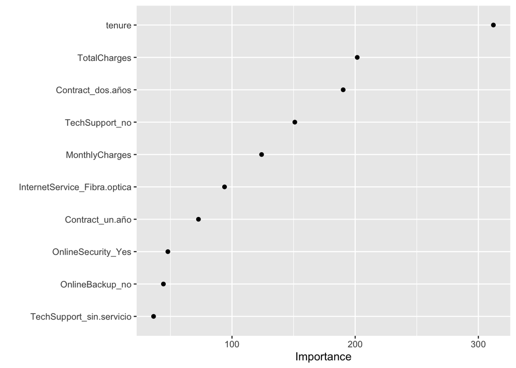

```r
library(vip)
rf_model_fin %>%
  vip(geom = "point")
```

# Modelo Boosting XGBoost*

Como parte del ejercicio de selección del mejor modelo para la determinación de la mejor estrategia para retención de clientes, se utiliza el algoritmo XGboost con la finalidad de elegir el modelo con mayor poder predictivo.

Para tal efecto, la aplicación del algoritmo XGboost inicia a partir de la receta establecida para los datos de abandono de clientes del servicio de telecomunicaciones.

### Especificación del modelo

```r
xgb_sp <- boost_tree(mtry = tune(), trees = tune(),
  loss_reduction = tune(), learn_rate= tune() ) %>%
  set_engine("xgboost") %>%
  set_mode("classification")

xgb_sp %>%
  translate()
```

```
## Boosted Tree Model Specification (classification)
##
## Main Arguments:
##   mtry = tune()
##   trees = tune()
##   learn_rate = tune()
##   loss_reduction = tune()
##
## Computational engine: xgboost
##
## Model fit template:
## parsnip::xgb_train(x = missing_arg(), y = missing_arg(), weights = missing_arg(),
##     colsample_bynode = tune(), nrounds = tune(), eta = tune(),
##     gamma = tune(), nthread = 1, verbose = 0)
```

### Afinamiento de Malla de búsqueda

Previo a establecer la malla de búsqueda el algoritmo requiere la data incorporada las funciones establecidas en la receta, por tal motivo se aplica prep y bake. Posteriormente, se obtiene la malla de búsqueda

```r
receta_prep = prep(receta, train)
finalize(mtry(), bake(receta_prep, new_data = NULL ))
```

```
## # Randomly Selected Predictors (quantitative)
## Range: [1, 31]
```

```r
set.seed(123)
xgb_grid <- xgb_sp %>%
  parameters() %>%
  finalize(bake(receta_prep, new_data = NULL)) %>%
  grid_latin_hypercube(size = 20)

xgb_grid
```

```
## # A tibble: 20 × 4
##     mtry trees learn_rate loss_reduction
##    <int> <int>      <dbl>          <dbl>
##  1     8   340    0.00151       5.11e- 4
##  2     9   514    0.00628       8.18e- 2
##  3     6  1881    0.00200       6.04e- 1
##  4    28  1318    0.169         5.69e- 9
##  5    14  1595    0.0503        1.08e- 2
##  6     3    65    0.00300       1.42e-10
##  7    22  1901    0.0388        1.42e- 4
##  8    28  1031    0.00557       2.23e- 5
##  9    21  1759    0.0131        1.31e+ 1
## 10    31   861    0.00106       4.42e-10
## 11     2  1186    0.0273        5.92e- 1
## 12    12  1406    0.00880       2.44e- 9
## 13    25  1652    0.0753        6.58e- 7
## 14    17   252    0.114         1.14e- 2
## 15    20   908    0.263         3.28e+ 0
## 16    19   791    0.0137        1.75e- 7
## 17    16   430    0.0687        6.27e- 8
## 18    26  1290    0.00392       1.25e- 6
## 19     5   683    0.0235        1.86e- 3
## 20    10   173    0.184         6.01e- 6
```

### Work Flow

```r
xgb_wflow <-
  workflow() %>%
  add_recipe(receta) %>%
  add_model(xgb_sp)

xgb_wflow
```

```
## ══ Workflow ════════════════════════════════════════════════════════════════════
## Preprocessor: Recipe
## Model: boost_tree()
##
## ── Preprocessor ────────────────────────────────────────────────────────────────
## 8 Recipe Steps
##
## • step_rm()
## • step_impute_knn()
## • step_normalize()
## • step_other()
## • step_novel()
## • step_dummy()
## • step_nzv()
## • step_upsample()
##
## ── Model ───────────────────────────────────────────────────────────────────────
## Boosted Tree Model Specification (classification)
##
## Main Arguments:
##   mtry = tune()
##   trees = tune()
##   learn_rate = tune()
##   loss_reduction = tune()
##
## Computational engine: xgboost
```

### Entrenamiento de Malla de Busqueda en la Crossvalidation - Xgboost

```r
set.seed(123)

xgb_tuned <- tune_grid(
  xgb_wflow,
  resamples= cv,
  grid = xgb_grid,
  metrics = metricas,
  control= control_grid(allow_par = T, save_pred = T)
  )

xgb_tuned
```

```
## # Tuning results
## # 5-fold cross-validation using stratification
## # A tibble: 5 × 5
##   splits              id    .metrics          .notes           .predictions
##   <list>              <chr> <list>            <list>           <list>
## 1 <split [4507/1127]> Fold1 <tibble [80 × 8]> <tibble [0 × 3]> <tibble>
## 2 <split [4507/1127]> Fold2 <tibble [80 × 8]> <tibble [0 × 3]> <tibble>
## 3 <split [4507/1127]> Fold3 <tibble [80 × 8]> <tibble [0 × 3]> <tibble>
## 4 <split [4507/1127]> Fold4 <tibble [80 × 8]> <tibble [0 × 3]> <tibble>
## 5 <split [4508/1126]> Fold5 <tibble [80 × 8]> <tibble [0 × 3]> <tibble>
```

### Mejor modelo

Evaluamos que modelo resulto mejor

```r
show_best(xgb_tuned, metric = 'accuracy', n = 10)
```

```
## # A tibble: 10 × 10
##     mtry trees learn_rate loss_reduction .metric  .estimator  mean     n std_err
##    <int> <int>      <dbl>          <dbl> <chr>    <chr>      <dbl> <int>   <dbl>
##  1    12  1406    0.00880        2.44e-9 accuracy binary     0.763     5 0.00593
##  2     2  1186    0.0273         5.92e-1 accuracy binary     0.762     5 0.00615
##  3    21  1759    0.0131         1.31e+1 accuracy binary     0.760     5 0.00621
##  4     6  1881    0.00200        6.04e-1 accuracy binary     0.759     5 0.00764
##  5     5   683    0.0235         1.86e-3 accuracy binary     0.759     5 0.00504
##  6    19   791    0.0137         1.75e-7 accuracy binary     0.759     5 0.00512
##  7     9   514    0.00628        8.18e-2 accuracy binary     0.758     5 0.00914
##  8    16   430    0.0687         6.27e-8 accuracy binary     0.757     5 0.00333
##  9     8   340    0.00151        5.11e-4 accuracy binary     0.756     5 0.00863
## 10    28  1031    0.00557        2.23e-5 accuracy binary     0.756     5 0.00652
## # ℹ 1 more variable: .config <chr>
```

```r
show_best(xgb_tuned, metric = 'sens', n = 10)
```

```
## # A tibble: 10 × 10
##     mtry trees learn_rate loss_reduction .metric .estimator  mean     n std_err
##    <int> <int>      <dbl>          <dbl> <chr>   <chr>      <dbl> <int>   <dbl>
##  1     8   340    0.00151       5.11e- 4 sens    binary     0.765     5 0.0110
##  2     3    65    0.00300       1.42e-10 sens    binary     0.761     5 0.0126
##  3    21  1759    0.0131        1.31e+ 1 sens    binary     0.759     5 0.0106
##  4    31   861    0.00106       4.42e-10 sens    binary     0.748     5 0.0179
##  5     9   514    0.00628       8.18e- 2 sens    binary     0.747     5 0.0119
##  6     6  1881    0.00200       6.04e- 1 sens    binary     0.746     5 0.0100
##  7    26  1290    0.00392       1.25e- 6 sens    binary     0.737     5 0.0144
##  8    28  1031    0.00557       2.23e- 5 sens    binary     0.737     5 0.0128
##  9    19   791    0.0137        1.75e- 7 sens    binary     0.728     5 0.00730
## 10    12  1406    0.00880       2.44e- 9 sens    binary     0.723     5 0.0116
## # ℹ 1 more variable: .config <chr>
```

```r
show_best(xgb_tuned, metric = 'spec', n = 10)
```

```
## # A tibble: 10 × 10
##     mtry trees learn_rate loss_reduction .metric .estimator  mean     n std_err
##    <int> <int>      <dbl>          <dbl> <chr>   <chr>      <dbl> <int>   <dbl>
##  1    28  1318    0.169    0.00000000569 spec    binary     0.803     5 0.00328
##  2    14  1595    0.0503   0.0108        spec    binary     0.800     5 0.00258
##  3    25  1652    0.0753   0.000000658   spec    binary     0.795     5 0.00206
##  4    22  1901    0.0388   0.000142      spec    binary     0.794     5 0.00375
##  5    16   430    0.0687   0.0000000627  spec    binary     0.787     5 0.00241
##  6    10   173    0.184    0.00000601    spec    binary     0.786     5 0.00320
##  7    17   252    0.114    0.0114        spec    binary     0.783     5 0.00170
##  8     2  1186    0.0273   0.592         spec    binary     0.779     5 0.00676
##  9    20   908    0.263    3.28          spec    binary     0.778     5 0.00472
## 10    12  1406    0.00880  0.00000000244 spec    binary     0.777     5 0.00552
## # ℹ 1 more variable: .config <chr>
```

```r
show_best(xgb_tuned, metric = 'bal_accuracy', n = 10)
```

```
## # A tibble: 10 × 10
##     mtry trees learn_rate loss_reduction .metric  .estimator  mean     n std_err
##    <int> <int>      <dbl>          <dbl> <chr>    <chr>      <dbl> <int>   <dbl>
##  1    21  1759    0.0131        1.31e+ 1 bal_acc… binary     0.760     5 0.00737
##  2     8   340    0.00151       5.11e- 4 bal_acc… binary     0.759     5 0.00890
##  3     6  1881    0.00200       6.04e- 1 bal_acc… binary     0.755     5 0.00802
##  4     9   514    0.00628       8.18e- 2 bal_acc… binary     0.755     5 0.00976
##  5     3    65    0.00300       1.42e-10 bal_acc… binary     0.753     5 0.00901
##  6    28  1031    0.00557       2.23e- 5 bal_acc… binary     0.750     5 0.00819
##  7    12  1406    0.00880       2.44e- 9 bal_acc… binary     0.750     5 0.00729
##  8    26  1290    0.00392       1.25e- 6 bal_acc… binary     0.750     5 0.00913
##  9    19   791    0.0137        1.75e- 7 bal_acc… binary     0.749     5 0.00573
## 10    31   861    0.00106       4.42e-10 bal_acc… binary     0.748     5 0.00919
## # ℹ 1 more variable: .config <chr>
```

### Selección del modelo final

```r
xgb_pars_fin <- select_best(xgb_tuned, metric = 'sens')
xgb_wflow_fin <-
  xgb_wflow %>%
  finalize_workflow(xgb_pars_fin)

xgb_wflow_fin
```

```
## ══ Workflow ════════════════════════════════════════════════════════════════════
## Preprocessor: Recipe
## Model: boost_tree()
##
## ── Preprocessor ────────────────────────────────────────────────────────────────
## 8 Recipe Steps
##
## • step_rm()
## • step_impute_knn()
## • step_normalize()
## • step_other()
## • step_novel()
## • step_dummy()
## • step_nzv()
## • step_upsample()
##
## ── Model ───────────────────────────────────────────────────────────────────────
## Boosted Tree Model Specification (classification)
##
## Main Arguments:
##   mtry = 8
##   trees = 340
##   learn_rate = 0.00151476799847829
##   loss_reduction = 0.000511172419399939
##
## Computational engine: xgboost
```

### Entrenar el modelo final

```r
xgb_fitted <- fit(xgb_wflow_fin, train)
xgb_fitted
```

```
## ══ Workflow [trained] ══════════════════════════════════════════════════════════
## Preprocessor: Recipe
## Model: boost_tree()
##
## ── Preprocessor ────────────────────────────────────────────────────────────────
## 8 Recipe Steps
##
## • step_rm()
## • step_impute_knn()
## • step_normalize()
## • step_other()
## • step_novel()
## • step_dummy()
## • step_nzv()
## • step_upsample()
##
## ── Model ───────────────────────────────────────────────────────────────────────
## ##### xgb.Booster
## raw: 1.2 Mb
## call:
##   xgboost::xgb.train(params = list(eta = 0.00151476799847829, max_depth = 6,
##     gamma = 0.000511172419399939, colsample_bytree = 1, colsample_bynode = 0.266666666666667,
##     min_child_weight = 1, subsample = 1), data = x$data, nrounds = 340L,
##     watchlist = x$watchlist, verbose = 0, nthread = 1, objective = "binary:logistic")
## params (as set within xgb.train):
##   eta = "0.00151476799847829", max_depth = "6", gamma = "0.000511172419399939", colsample_bytree = "1", colsample_bynode = "0.266666666666667", min_child_weight = "1", subsample = "1", nthread = "1", objective = "binary:logistic", validate_parameters = "TRUE"
## xgb.attributes:
##   niter
## callbacks:
##   cb.evaluation.log()
## # of features: 30
## niter: 340
## nfeatures : 30
## evaluation_log:
##     iter training_logloss
##        1        0.6926047
##        2        0.6920662
## ---
##      339        0.5686884
##      340        0.5684188
```

### Selección del modelo

```r
xgb_model_fin <- pull_workflow_fit(xgb_fitted)
xgb_model_fin
```

```
## parsnip model object
##
## ##### xgb.Booster
## raw: 1.2 Mb
## call:
##   xgboost::xgb.train(params = list(eta = 0.00151476799847829, max_depth = 6,
##     gamma = 0.000511172419399939, colsample_bytree = 1, colsample_bynode = 0.266666666666667,
##     min_child_weight = 1, subsample = 1), data = x$data, nrounds = 340L,
##     watchlist = x$watchlist, verbose = 0, nthread = 1, objective = "binary:logistic")
## params (as set within xgb.train):
##   eta = "0.00151476799847829", max_depth = "6", gamma = "0.000511172419399939", colsample_bytree = "1", colsample_bynode = "0.266666666666667", min_child_weight = "1", subsample = "1", nthread = "1", objective = "binary:logistic", validate_parameters = "TRUE"
## xgb.attributes:
##   niter
## callbacks:
##   cb.evaluation.log()
## # of features: 30
## niter: 340
## nfeatures : 30
## evaluation_log:
##     iter training_logloss
##        1        0.6926047
##        2        0.6920662
## ---
##      339        0.5686884
##      340        0.5684188
```

### Evaluación del modelo en la data de entrenamiento y prueba

```r
train %>%
  predict(xgb_fitted , new_data = . ) %>%
  mutate(Real= train$Churn) %>%
  conf_mat(truth = Real, estimate = .pred_class ) %>%
  summary
```

```
## # A tibble: 13 × 3
##    .metric              .estimator .estimate
##    <chr>                <chr>          <dbl>
##  1 accuracy             binary         0.777
##  2 kap                  binary         0.494
##  3 sens                 binary         0.787
##  4 spec                 binary         0.773
##  5 ppv                  binary         0.556
##  6 npv                  binary         0.909
##  7 mcc                  binary         0.510
##  8 j_index              binary         0.560
##  9 bal_accuracy         binary         0.780
## 10 detection_prevalence binary         0.375
## 11 precision            binary         0.556
## 12 recall               binary         0.787
## 13 f_meas               binary         0.652
```

```r
test %>%
  predict(xgb_fitted , new_data = . ) %>%
  mutate(Real= test$Churn) %>%
  conf_mat(truth = Real, estimate = .pred_class ) %>%
  summary
```

```
## # A tibble: 13 × 3
##    .metric              .estimator .estimate
##    <chr>                <chr>          <dbl>
##  1 accuracy             binary         0.765
##  2 kap                  binary         0.460
##  3 sens                 binary         0.738
##  4 spec                 binary         0.775
##  5 ppv                  binary         0.542
##  6 npv                  binary         0.891
##  7 mcc                  binary         0.471
##  8 j_index              binary         0.513
##  9 bal_accuracy         binary         0.756
## 10 detection_prevalence binary         0.361
## 11 precision            binary         0.542
## 12 recall               binary         0.738
## 13 f_meas               binary         0.625
```

### Importancia de las variables en el modelo

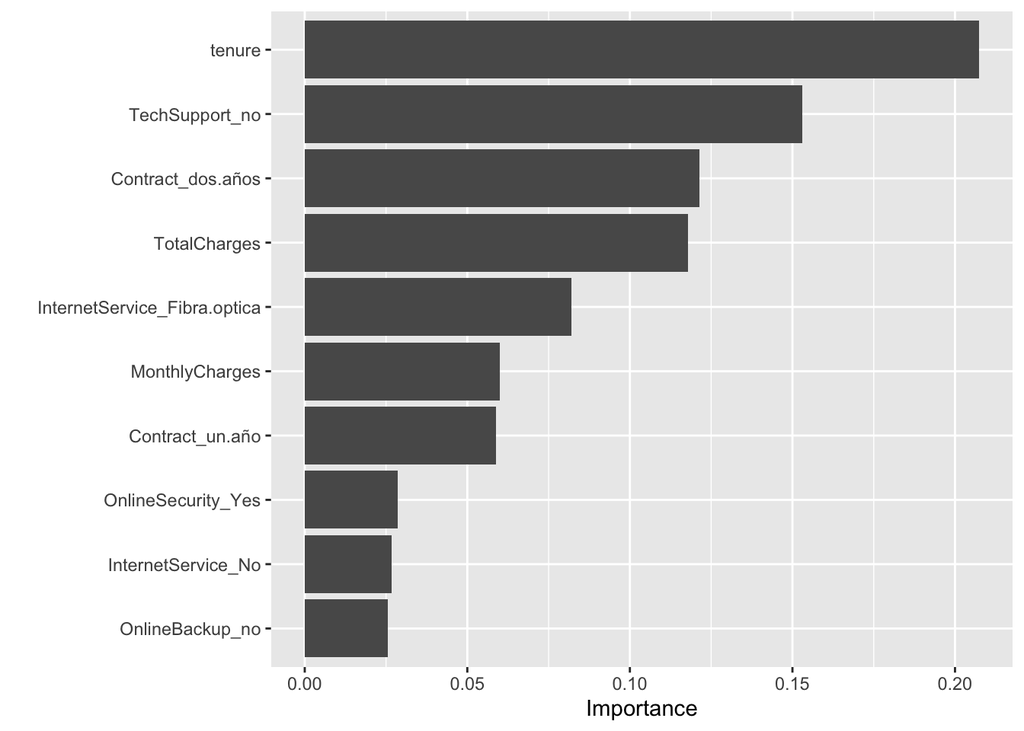

```r
vip(xgb_model_fin)
```

Analizando la importancia de las variables en el modelo se verifica que el gasto mensual y total presentan una alta importancia en las variables sin embargo el gasto total es una combinación lineal del gasto mensual, por lo que se podría excluir del modelo una de las variabales para probar si incrementa su capacidad de predicción con respecto a sensibilidad y bal_accuracy.

# Conclusión

Del análisis realizado se evidencia que ambos modelos (Random Forest y Xgboost ) presentan muy buena estimación con relación a sensibilidad, es decir con la capacidad de predicción de los individuos que abandonan el servicio, no obstante Xgboost presenta un resultado superior en el test de prueba (0.74 > 0.72), por tanto el modelo seleccionado es Xgboost.